# Decision Tree & Random Forrest

```python
# Import required packages for this chapter

import pandas as pd
from sklearn.model_selection import train_test_split
from sklearn.ensemble import RandomForestClassifier
from sklearn.tree import DecisionTreeClassifier
import matplotlib.pyplot as plt
from dmba import plotDecisionTree
```

# Competitive Auctions on eBay.com

The file *eBayauctions.csv* contains information on 1972 auctions that transacted on eBay.com during May–June 2004. The goal is to use these data to build a model that will classify auctions as competitive or noncompetitive. A *competitive auction* is defined as an auction with at least two bids placed on the item auctioned. The data include variables that describe the item (auction category), the seller (his/her eBay rating), and the auction terms that the seller selected (auction duration, opening price, currency, day-of-week of auction close). In addition, we have the price at which the auction closed. The task is to predict whether or not the auction will be competitive based on item (auction category), seller information (seller rating), and auction characteristics (duration and open price).

**Data Preprocessing.** Convert variable *Duration* into a categorical variable. Split the data into training (60%) and validation (40%) datasets.

```python
# Load the data into ebay_df dataframe

ebay_df = pd.read_csv("C:/Users/erwin/Desktop/MIS536/Module 7/Lab7/Lab7_dataset/eBayauctions.csv")

# Use critical functions to explore the dataframe using print() to show results

print(ebay_df.head(), "\n")

print(ebay_df.shape, "\n")

print(ebay_df.describe)
```

```
           Category currency  sellerRating  Duration endDay  ClosePrice  \
0  Music/Movie/Game       US          3249         5    Mon        0.01
1  Music/Movie/Game       US          3249         5    Mon        0.01
2  Music/Movie/Game       US          3249         5    Mon        0.01
3  Music/Movie/Game       US          3249         5    Mon        0.01
4  Music/Movie/Game       US          3249         5    Mon        0.01

   OpenPrice  Competitive?
0       0.01             0
1       0.01             0
2       0.01             0
3       0.01             0
4       0.01             0

(1972, 8)
```

[output cut: 28 more lines]

```python
# clean the dataset.
# drop all the non-usable variables
# convert categorical variables into indicator while dropping the first column of each of them to create n-1 dummies for n categorical variables.

### Step 1 drop the non-usable variables
ebay_df = ebay_df.drop("currency", axis=1)
ebay_df = ebay_df.drop("endDay", axis=1)
ebay_df = ebay_df.drop("ClosePrice", axis=1)
print(ebay_df.head())
```

```
           Category  sellerRating  Duration  OpenPrice  Competitive?
0  Music/Movie/Game          3249         5       0.01             0
1  Music/Movie/Game          3249         5       0.01             0
2  Music/Movie/Game          3249         5       0.01             0
3  Music/Movie/Game          3249         5       0.01             0
4  Music/Movie/Game          3249         5       0.01             0
```

```python
### Step 3 make dummy/indicator variables for category
cat = []

for i in ebay_df.Category:
    if i not in cat:
        cat.append(i)
print(cat)

dummy_var = pd.get_dummies(ebay_df['Category']).rename(columns = lambda x: 'Cat:' + str(x))

dummy_vartwo = pd.get_dummies(ebay_df['Duration']).rename(columns = lambda x: 'Dur:' + str(x))

ebay_df = pd.concat([ebay_df, dummy_var], axis = 1)
ebay_df = pd.concat([ebay_df, dummy_vartwo], axis = 1)

print(ebay_df.head(20))
```

```
['Music/Movie/Game', 'Automotive', 'SportingGoods', 'Home/Garden', 'Books', 'Collectibles', 'Business/Industrial', 'Toys/Hobbies', 'Electronics', 'Computer', 'EverythingElse', 'Clothing/Accessories', 'Coins/Stamps', 'Antique/Art/Craft', 'Jewelry', 'Pottery/Glass', 'Health/Beauty', 'Photography']
            Category  sellerRating  Duration  OpenPrice  Competitive?  \
0   Music/Movie/Game          3249         5       0.01             0
1   Music/Movie/Game          3249         5       0.01             0
2   Music/Movie/Game          3249         5       0.01             0
3   Music/Movie/Game          3249         5       0.01             0
4   Music/Movie/Game          3249         5       0.01             0
5   Music/Movie/Game          3249         5       0.01             0
6   Music/Movie/Game          3249         5       0.01             0
7   Music/Movie/Game          3249         5       0.01             0
8   Music/Movie/Game          3249         5       0.01             0
9   Music/Movie/Game          3249         5       0.01             0
10  Music/Movie/Game          3249         5       0.01             0
11  Music/Movie/Game          3249         5       0.01             0
12  Music/Movie/Game          3249         5       0.01             0
```

[output cut: 97 more lines]

```python
# remove question mark from response name
# convert variable Duration to categorical data type
# Separate out predictors and outcome variable

print(ebay_df['Competitive?'])

ebay_df.rename(columns = {'Competitive?': 'Competitive'}, inplace = True)

print(ebay_df.columns)
```

```
0       0
1       0
2       0
3       0
4       0
       ..
1967    0
1968    1
1969    0
1970    1
1971    0
Name: Competitive?, Length: 1972, dtype: int64
Index(['Category', 'sellerRating', 'Duration', 'OpenPrice', 'Competitive',
       'Cat:Antique/Art/Craft', 'Cat:Automotive', 'Cat:Books',
       'Cat:Business/Industrial', 'Cat:Clothing/Accessories',
       'Cat:Coins/Stamps', 'Cat:Collectibles', 'Cat:Computer',
       'Cat:Electronics', 'Cat:EverythingElse', 'Cat:Health/Beauty',
       'Cat:Home/Garden', 'Cat:Jewelry', 'Cat:Music/Movie/Game',
       'Cat:Photography', 'Cat:Pottery/Glass', 'Cat:SportingGoods',
       'Cat:Toys/Hobbies', 'Dur:1', 'Dur:3', 'Dur:5', 'Dur:7', 'Dur:10'],
      dtype='object')
```

```python
y = ebay_df['Competitive']
X = ebay_df[['sellerRating','OpenPrice','Cat:Antique/Art/Craft','Cat:Automotive', 'Cat:Books',
       'Cat:Business/Industrial', 'Cat:Clothing/Accessories',
       'Cat:Coins/Stamps', 'Cat:Collectibles', 'Cat:Computer',
       'Cat:Electronics', 'Cat:EverythingElse', 'Cat:Health/Beauty',
       'Cat:Home/Garden', 'Cat:Jewelry', 'Cat:Music/Movie/Game',
       'Cat:Photography', 'Cat:Pottery/Glass', 'Cat:SportingGoods',
       'Cat:Toys/Hobbies', 'Dur:1', 'Dur:3', 'Dur:5', 'Dur:7', 'Dur:10']]

print(X.head(),"\n",y.head())
```

```
   sellerRating  OpenPrice  Cat:Antique/Art/Craft  Cat:Automotive  Cat:Books  \
0          3249       0.01                      0               0          0
1          3249       0.01                      0               0          0
2          3249       0.01                      0               0          0
3          3249       0.01                      0               0          0
4          3249       0.01                      0               0          0

   Cat:Business/Industrial  Cat:Clothing/Accessories  Cat:Coins/Stamps  \
0                        0                         0                 0
1                        0                         0                 0
2                        0                         0                 0
3                        0                         0                 0
4                        0                         0                 0

   Cat:Collectibles  Cat:Computer  ...  Cat:Music/Movie/Game  Cat:Photography  \
```

[output cut: 27 more lines]

```python
# partition the data into training (60%) and validation (40%) sets. use random_state=1 for reproducibility of results
training_X, valid_X, training_y, valid_y = train_test_split(X,y, test_size = 0.4, random_state = 1)
```

```
0.6920152091254753
```

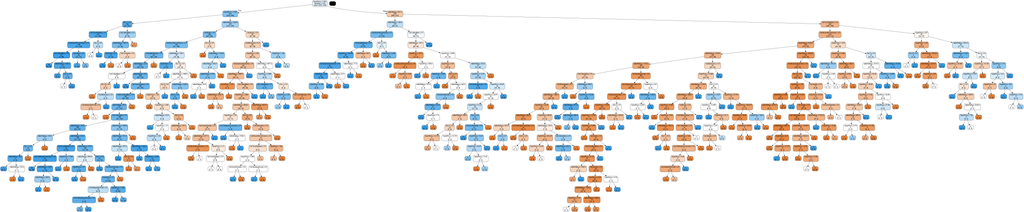

```python
# Calculate the scores of the trees with 1-20 max_depth
# graph the results

tree = DecisionTreeClassifier(random_state = 1, max_depth = 20)

tree.fit(training_X,training_y)

print(tree.score(valid_X,valid_y))
plotDecisionTree(tree, feature_names = training_X.columns)
```

```
[0.6641318124207858, 0.7072243346007605, 0.7249683143219265, 0.7072243346007605, 0.6907477820025348, 0.7008871989860583, 0.714828897338403, 0.7249683143219265, 0.6996197718631179, 0.7034220532319392, 0.6983523447401775, 0.6932826362484157, 0.6844106463878327, 0.6856780735107731, 0.6869455006337135, …
```

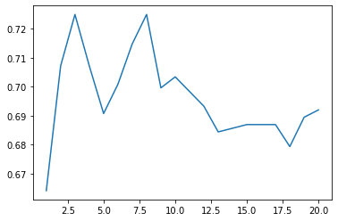

```python
scores = []
for i in range(1,21):
    tree = DecisionTreeClassifier(random_state = 1, max_depth = i)
    tree.fit(training_X, training_y)
    scores.append(tree.score(valid_X,valid_y))

print(scores)

plt.plot(range(1,21), scores)
plt.show()
```

```
0.7072243346007605
```

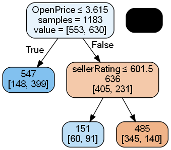

```python
# prune the tree with the max_depth you have discovered to provide the best fit.
# set max_depth=3, min_samples_split=50, min_impurity_decrease=0.01, random_state=1 for your classifier
# print the score the pruned tree.
pruned_tree = DecisionTreeClassifier(random_state = 1, max_depth = 3, min_samples_split = 50, min_impurity_decrease = 0.01)
pruned_tree.fit(training_X, training_y)
print(pruned_tree.score(valid_X,valid_y))

plotDecisionTree(pruned_tree, feature_names = training_X.columns)
```

```python
# Which features tend to be more relevant? Use data to back your answer.
importances = pruned_tree.feature_importances_

for i in range(len(importances)):
    print(valid_X.columns[i], ": ", importances[i])

### the most important features were sellerRating and OpenPrice
```

```
sellerRating :  0.2234990274051515
OpenPrice :  0.7765009725948484
Cat:Antique/Art/Craft :  0.0
Cat:Automotive :  0.0
Cat:Books :  0.0
Cat:Business/Industrial :  0.0
Cat:Clothing/Accessories :  0.0
Cat:Coins/Stamps :  0.0
Cat:Collectibles :  0.0
Cat:Computer :  0.0
Cat:Electronics :  0.0
Cat:EverythingElse :  0.0
Cat:Health/Beauty :  0.0
Cat:Home/Garden :  0.0
Cat:Jewelry :  0.0
Cat:Music/Movie/Game :  0.0
Cat:Photography :  0.0
Cat:Pottery/Glass :  0.0
Cat:SportingGoods :  0.0
Cat:Toys/Hobbies :  0.0
Dur:1 :  0.0
Dur:3 :  0.0
Dur:5 :  0.0
Dur:7 :  0.0
Dur:10 :  0.0
```